# Project Foundations for Data Science: FoodHub Data Analysis

**Marks: 60**

### Context

The number of restaurants in New York is increasing day by day. Lots of students and busy professionals rely on those restaurants due to their hectic lifestyles. Online food delivery service is a great option for them. It provides them with good food from their favorite restaurants. A food aggregator company FoodHub offers access to multiple restaurants through a single smartphone app.

The app allows the restaurants to receive a direct online order from a customer. The app assigns a delivery person from the company to pick up the order after it is confirmed by the restaurant. The delivery person then uses the map to reach the restaurant and waits for the food package. Once the food package is handed over to the delivery person, he/she confirms the pick-up in the app and travels to the customer's location to deliver the food. The delivery person confirms the drop-off in the app after delivering the food package to the customer. The customer can rate the order in the app. The food aggregator earns money by collecting a fixed margin of the delivery order from the restaurants.

### Objective

The food aggregator company has stored the data of the different orders made by the registered customers in their online portal. They want to analyze the data to get a fair idea about the demand of different restaurants which will help them in enhancing their customer experience. Suppose you are hired as a Data Scientist in this company and the Data Science team has shared some of the key questions that need to be answered. Perform the data analysis to find answers to these questions that will help the company to improve the business.

### Data Description

The data contains the different data related to a food order. The detailed data dictionary is given below.

### Data Dictionary

- order_id: Unique ID of the order
- customer_id: ID of the customer who ordered the food
- restaurant_name: Name of the restaurant
- cuisine_type: Cuisine ordered by the customer
- cost: Cost of the order
- day_of_the_week: Indicates whether the order is placed on a weekday or weekend (The weekday is from Monday to Friday and the weekend is Saturday and Sunday)
- rating: Rating given by the customer out of 5
- food_preparation_time: Time (in minutes) taken by the restaurant to prepare the food. This is calculated by taking the difference between the timestamps of the restaurant's order confirmation and the delivery person's pick-up confirmation.
- delivery_time: Time (in minutes) taken by the delivery person to deliver the food package. This is calculated by taking the difference between the timestamps of the delivery person's pick-up confirmation and drop-off information

### Let us start by importing the required libraries

```python
# import libraries for data manipulation
import numpy as np
import pandas as pd

# Import libraries for data visualization
import matplotlib.pyplot as plt
import seaborn as sns
# Command to tell Python to actually display the graphs
%matplotlib inline
```

```python
from google.colab import drive
drive.mount('/content/drive')
```

### Understanding the structure of the data

```python
# read the data
df = pd.read_csv('/content/drive/MyDrive/foodhub_order.csv')
# returns the first 5 rows
df.head()
```

|  | order_id | customer_id | restaurant_name | cuisine_type | cost_of_the_order | day_of_the_week | rating | food_preparation_time | delivery_time |
| --- | --- | --- | --- | --- | --- | --- | --- | --- | --- |
| 0 | 1477147 | 337525 | Hangawi | Korean | 30.75 | Weekend | Not given | 25 | 20 |
| 1 | 1477685 | 358141 | Blue Ribbon Sushi Izakaya | Japanese | 12.08 | Weekend | Not given | 25 | 23 |
| 2 | 1477070 | 66393 | Cafe Habana | Mexican | 12.23 | Weekday | 5 | 23 | 28 |
| 3 | 1477334 | 106968 | Blue Ribbon Fried Chicken | American | 29.20 | Weekend | 3 | 25 | 15 |
| 4 | 1478249 | 76942 | Dirty Bird to Go | American | 11.59 | Weekday | 4 | 25 | 24 |

#### Observations:

The DataFrame has 9 columns as mentioned in the Data Dictionary. Data in each row corresponds to the order placed by a customer.

### **Question 1:** How many rows and columns are present in the data? [0.5 mark]

```python
df.shape
```

```
(1898, 9)
```

#### Observations:

1. The dataset contains 1898 rows and 9 columns.

### **Question 2:** What are the datatypes of the different columns in the dataset? (The info() function can be used) [0.5 mark]

```python
df.info()
```

```
<class 'pandas.core.frame.DataFrame'>
RangeIndex: 1898 entries, 0 to 1897
Data columns (total 9 columns):
 #   Column                 Non-Null Count  Dtype
---  ------                 --------------  -----
 0   order_id               1898 non-null   int64
 1   customer_id            1898 non-null   int64
 2   restaurant_name        1898 non-null   object
 3   cuisine_type           1898 non-null   object
 4   cost_of_the_order      1898 non-null   float64
 5   day_of_the_week        1898 non-null   object
 6   rating                 1898 non-null   object
 7   food_preparation_time  1898 non-null   int64
 8   delivery_time          1898 non-null   int64
dtypes: float64(1), int64(4), object(4)
memory usage: 133.6+ KB
```

### **Question 3:** Are there any missing values in the data? If yes, treat them using an appropriate method. [1 mark]

```python
df.isnull()
```

|  | order_id | customer_id | restaurant_name | cuisine_type | cost_of_the_order | day_of_the_week | rating | food_preparation_time | delivery_time |
| --- | --- | --- | --- | --- | --- | --- | --- | --- | --- |
| 0 | False | False | False | False | False | False | False | False | False |
| 1 | False | False | False | False | False | False | False | False | False |
| 2 | False | False | False | False | False | False | False | False | False |
| 3 | False | False | False | False | False | False | False | False | False |
| 4 | False | False | False | False | False | False | False | False | False |
| ... | ... | ... | ... | ... | ... | ... | ... | ... | ... |
| 1893 | False | False | False | False | False | False | False | False | False |
| 1894 | False | False | False | False | False | False | False | False | False |
| 1895 | False | False | False | False | False | False | False | False | False |
| 1896 | False | False | False | False | False | False | False | False | False |
| 1897 | False | False | False | False | False | False | False | False | False |

1898 rows × 9 columns

```python
missing_values = df.isna().sum()

print(missing_values)
```

```
order_id                 0
customer_id              0
restaurant_name          0
cuisine_type             0
cost_of_the_order        0
day_of_the_week          0
rating                   0
food_preparation_time    0
delivery_time            0
dtype: int64
```

```python
df.isnull().sum()
```

```
order_id                 0
customer_id              0
restaurant_name          0
cuisine_type             0
cost_of_the_order        0
day_of_the_week          0
rating                   0
food_preparation_time    0
delivery_time            0
dtype: int64
```

```python
df.duplicated().sum()
```

```
0
```

#### Observations:

1. With no missing values, the dataset's completeness ensures a robust and accurate analysis process, eliminating the need for data imputation. However, further data exploration remains crucial to understand the underlying patterns and trends.

### **Question 4:** Check the statistical summary of the data. What is the minimum, average, and maximum time it takes for food to be prepared once an order is placed? [2 marks]

```python
food_preparation_time_stats = df['food_preparation_time'].describe()
print (food_preparation_time_stats)
```

```
count    1898.000000
mean       27.371970
std         4.632481
min        20.000000
25%        23.000000
50%        27.000000
75%        31.000000
max        35.000000
Name: food_preparation_time, dtype: float64
```

#### Observations:

1. The analysis of food preparation times reveals a consistent performance across restaurants. Orders take a minimum of 20 minutes and a maximum of 35 minutes to prepare, with an average time of approximately 27.37 minutes. This suggests effective operations across various cuisines and order types.

### **Question 5:** How many orders are not rated? [1 mark]

```python
# Find the number of orders that are not rated
not_rated_orders = df[df['rating'] == 'Not given'].shape[0]

print(not_rated_orders)
```

```
736
```

#### Observations:

1. A total of 736 orders in the dataset have not received a rating, possibly due to customers choosing not to rate their experience or the orders being recent.

### Exploratory Data Analysis (EDA)

### **Question 6:** Explore all the variables and provide observations on their distributions. (Generally, histograms, boxplots, countplots, etc. are used for univariate exploration.) [9 marks]

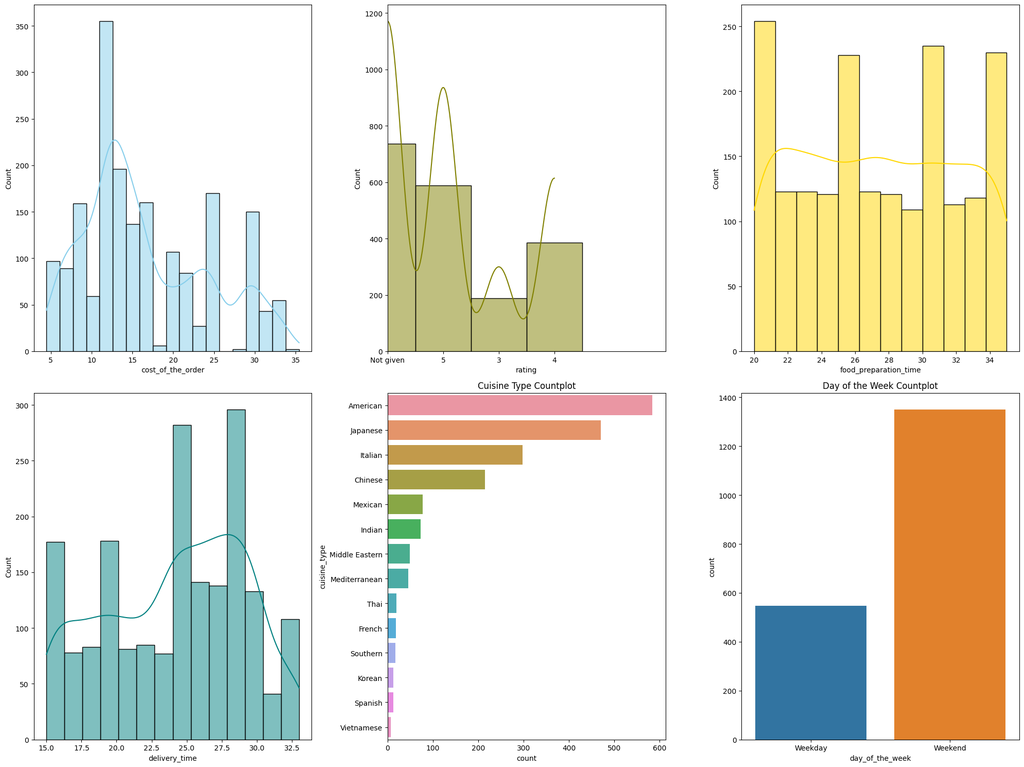

```python
f, axes = plt.subplots(2, 3, figsize=(20, 15))

# Plot a histogram and kernel density estimate for cost_of_the_order
sns.histplot(data=df, x="cost_of_the_order", kde=True, color="skyblue", ax=axes[0, 0])

# Plot a histogram and kernel density estimate for rating (excluding NaN values)
sns.histplot(data=df, x="rating", kde=True, color="olive", ax=axes[0, 1])
axes[0, 1].set_xlim(0, 5)  # Ratings are usually on a scale of 0-5

# Plot a histogram and kernel density estimate for food_preparation_time
sns.histplot(data=df, x="food_preparation_time", kde=True, color="gold", ax=axes[0, 2])

# Plot a histogram and kernel density estimate for delivery_time
sns.histplot(data=df, x="delivery_time", kde=True, color="teal", ax=axes[1, 0])

# Plot a countplot for cuisine_type
sns.countplot(data=df, y="cuisine_type", order=df["cuisine_type"].value_counts().index, ax=axes[1, 1])
axes[1, 1].set_title("Cuisine Type Countplot")

# Plot a countplot for day_of_the_week
sns.countplot(data=df, x="day_of_the_week", order=["Weekday", "Weekend"], ax=axes[1, 2])
axes[1, 2].set_title("Day of the Week Countplot")

plt.tight_layout()
plt.show()
```

### **Question 7**: Which are the top 5 restaurants in terms of the number of orders received? [1 mark]

```python
# Find the top 5 restaurants in terms of number of orders received
top_5_restaurants = df['restaurant_name'].value_counts().head(5)

print(top_5_restaurants)
```

```
Shake Shack                  219
The Meatball Shop            132
Blue Ribbon Sushi            119
Blue Ribbon Fried Chicken     96
Parm                          68
Name: restaurant_name, dtype: int64
```

#### Observations:

1. Shake Shack is the most frequented restaurant on the platform, with 219 orders. The Meatball Shop and Blue Ribbon Sushi are also popular, with 132 and 119 orders respectively. Blue Ribbon Fried Chicken and Parm round out the top five, receiving 96 and 68 orders respectively. This suggests customer preferences for these establishments, possibly due to factors such as menu offerings, service quality, or price.

### **Question 8**: Which is the most popular cuisine on weekends? [1 mark]

```python
# Find the most popular cuisine on weekends
most_popular_cuisine_weekends = df[df['day_of_the_week'] == 'Weekend']['cuisine_type'].value_counts().head(1)

print (most_popular_cuisine_weekends)
```

```
American    415
Name: cuisine_type, dtype: int64
```

#### Observations:

1. The analysis of weekend orders reveals that "American" is the most popular cuisine among customers. This observation suggests a preference for American cuisine during weekends, which could be due to various factors such as the type of dishes offered, the convenience of ordering, or cultural eating habits. Understanding these preferences can help inform strategies for restaurant promotion and menu planning, particularly for weekends.

### **Question 9**: What percentage of the orders cost more than 20 dollars? [2 marks]

```python
# Filter the DataFrame for orders that cost more than 20 dollars
df_greater_than_20 = df[df['cost_of_the_order'] > 20]

# Calculate the percentage of expensive orders relative to the total number of orders
percentage = (df_greater_than_20.shape[0] / df.shape[0]) * 100

print("The percentage of orders that cost more than 20 dollars is:", round(percentage, 2), '%')
```

```
The percentage of orders that cost more than 20 dollars is: 29.24 %
```

#### Observations:

1. Approximately 29.24% of the orders cost more than 20 dollars. This suggests that nearly a third of all orders on the platform are for amounts exceeding 20 dollars.

### **Question 10**: What is the mean order delivery time? [1 mark]

```python
# Calculate the mean order delivery time
mean_delivery_time = df['delivery_time'].mean()

print("The mean order delivery time is", round (mean_delivery_time, 2), 'minutes')
```

```
The mean order delivery time is 24.16 minutes
```

### **Question 11:** The company has decided to give 20% discount vouchers to the top 3 most frequent customers. Find the IDs of these customers and the number of orders they placed. [1 mark]

```python
# Get the frequency of each customer's ID
customer_order_counts = df['customer_id'].value_counts()

# Sort the customers based on the number of orders they placed in descending order
sorted_customers = customer_order_counts.sort_values(ascending=False)

# Get the top 3 most frequent customers and their corresponding order counts
top_3_customers = sorted_customers.head(3)

# Print the result
print("Top 3 most frequent customers:")
print(top_3_customers)
```

```
Top 3 most frequent customers:
52832    13
47440    10
83287     9
Name: customer_id, dtype: int64
```

#### Observations:

1. The top three customers, who have placed 13, 10, and 9 orders respectively, will receive 20% discount vouchers. This strategy rewards these frequent customers, potentially encouraging further orders. Other factors, such as total revenue from these customers, should also be considered for a complete understanding of their value.

### **Question 12**: Perform a multivariate analysis to explore relationships between the important variables in the dataset. (It is a good idea to explore relations between numerical variables as well as relations between numerical and categorical variables) [10 marks]

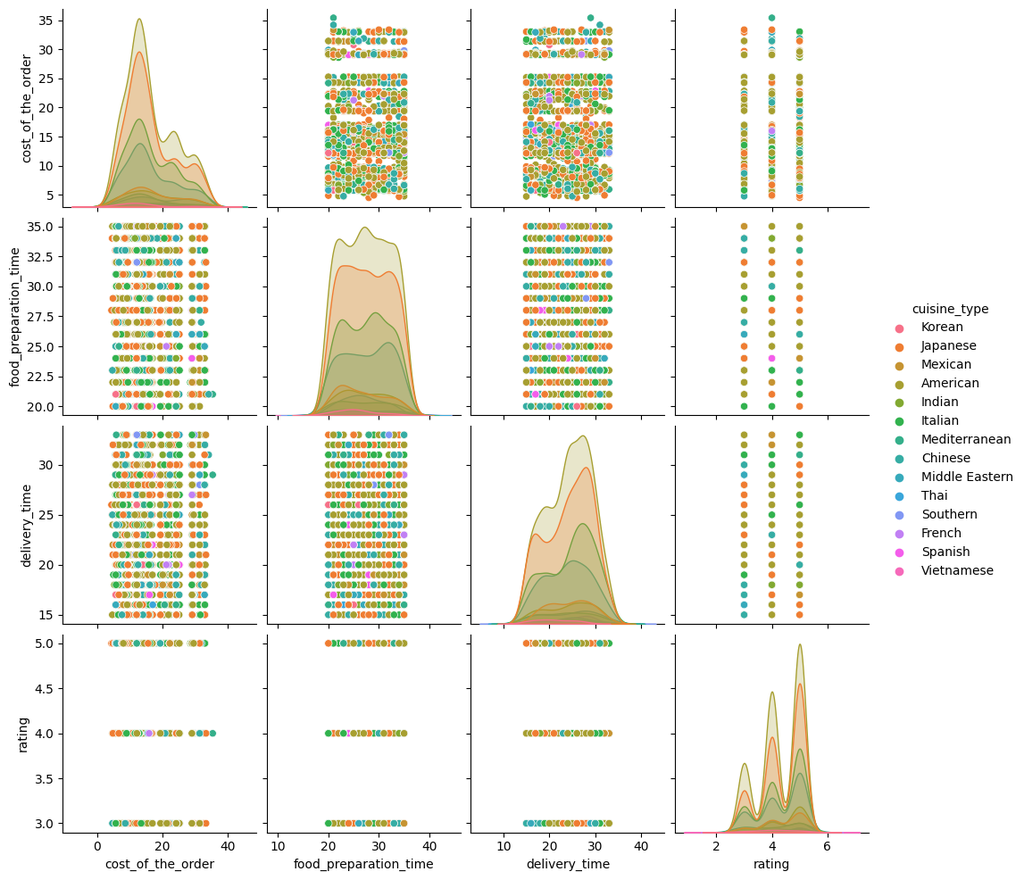

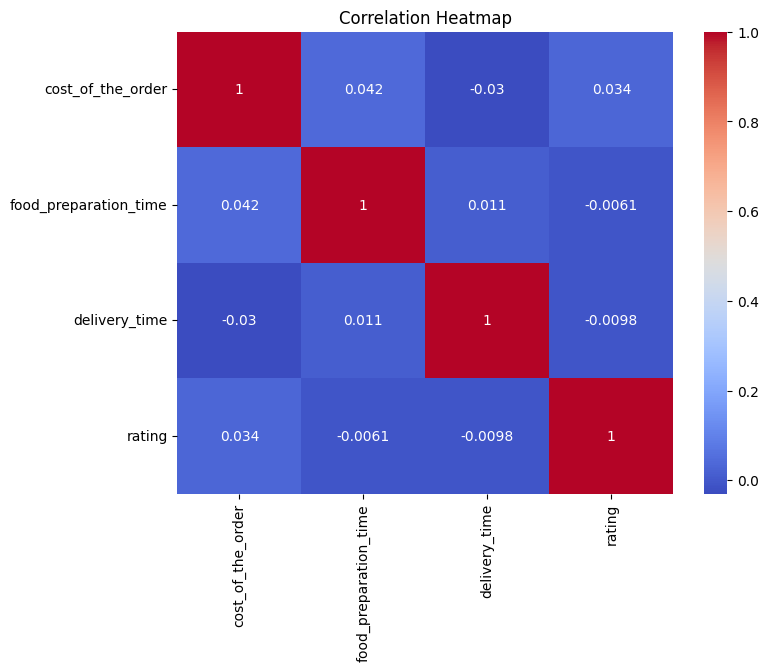

```python
# Convert 'rating' column to numeric, setting 'Not given' as NaN
df['rating'] = pd.to_numeric(df['rating'], errors='coerce')

# Plotting pairwise relationships in a dataset
sns.pairplot(df[['cost_of_the_order', 'food_preparation_time', 'delivery_time', 'rating', 'cuisine_type']], hue='cuisine_type')
plt.show()

# Plotting correlation heatmap for numerical variables
corr = df[['cost_of_the_order', 'food_preparation_time', 'delivery_time', 'rating']].corr()

plt.figure(figsize=(8, 6))
sns.heatmap(corr, annot=True, cmap='coolwarm')
plt.title('Correlation Heatmap')
plt.show()
```

### **Question 13:** The company wants to provide a promotional offer in the advertisement of the restaurants. The condition to get the offer is that the restaurants must have a rating count of more than 50 and the average rating should be greater than 4. Find the restaurants fulfilling the criteria to get the promotional offer. [3 marks]

```python
# Group by 'restaurant_name' and calculate the count and mean of 'rating' for each restaurant
grouped_rating_restaurant = df.groupby('restaurant_name')['rating'].agg(['count', 'mean'])

# Filter the restaurants with a rating count of more than 50 and an average rating greater than 4
promotional_offer_restaurants = grouped_rating_restaurant[(grouped_rating_restaurant['count'] > 50) & (grouped_rating_restaurant['mean'] > 4)]

# Print the restaurants fulfilling the criteria to get the promotional offer
print("Restaurants eligible for the promotional offer:")
print(promotional_offer_restaurants)
```

```
Restaurants eligible for the promotional offer:
                           count      mean
restaurant_name
Blue Ribbon Fried Chicken     64  4.328125
Blue Ribbon Sushi             73  4.219178
Shake Shack                  133  4.278195
The Meatball Shop             84  4.511905
```

### **Question 14:** The company charges the restaurant 25% on the orders having cost greater than 20 dollars and 15% on the orders having cost greater than 5 dollars. Find the net revenue generated by the company across all orders. [3 marks]

```python
# Calculate the revenue from each order based on the charging policy
df['revenue'] = 0  # Initialize a new column 'revenue' with default value 0

# Calculate revenue for orders with cost greater than $20 (25% charge)
df.loc[df['cost_of_the_order'] > 20, 'revenue'] = df['cost_of_the_order'] * 0.25

# Calculate revenue for orders with cost greater than $5 but less than or equal to $20 (15% charge)
df.loc[(df['cost_of_the_order'] > 5) & (df['cost_of_the_order'] <= 20), 'revenue'] = df['cost_of_the_order'] * 0.15

# Calculate the net revenue generated by the company across all orders
net_revenue = df['revenue'].sum()

# Print the net revenue
print("Net revenue generated by the company across all orders:", net_revenue)
```

```
Net revenue generated by the company across all orders: 6166.303
```

#### Observations:

1. The total income accrued by the company from all orders, given the specified commission structure, amounts to roughly 6,166.30 dollars. This sum is the result of a 25% charge on orders with a cost exceeding 20 dollars and a 15% charge on orders priced between 5 dollars and 20 dollars.

### **Question 15:** The company wants to analyze the total time required to deliver the food. What percentage of orders take more than 60 minutes to get delivered from the time the order is placed? (The food has to be prepared and then delivered.) [2 marks]

```python
# Calculate the total time required to deliver the food (food preparation time + delivery time)
df['total_delivery_time'] = df['food_preparation_time'] + df['delivery_time']

# Calculate the percentage of orders that take more than 60 minutes for delivery
num_orders_gt_60_min = df[df['total_delivery_time'] > 60].shape[0]
total_orders = df.shape[0]
percentage_gt_60_min = (num_orders_gt_60_min / total_orders) * 100

# Print the percentage of orders that take more than 60 minutes for delivery
print("Percentage of orders that take more than 60 minutes for delivery:", percentage_gt_60_min)
```

```
Percentage of orders that take more than 60 minutes for delivery: 10.537407797681771
```

#### Observations:

1. Roughly 10.54% of the orders require more than 60 minutes for the entire process, from placement to delivery. This calculation includes the time required for both preparing the food and delivering the order. This indicates that just over one in ten orders might take an hour or more to be delivered to the customer from the time it is ordered.

### **Question 16:** The company wants to analyze the delivery time of the orders on weekdays and weekends. How does the mean delivery time vary during weekdays and weekends? [2 marks]

```python
# Convert the 'delivery_time' column to numeric (integer or float)
df['delivery_time'] = pd.to_numeric(df['delivery_time'], errors='coerce')

# Group the data by 'day_of_the_week' and calculate the mean delivery time for each group
mean_delivery_time_by_day = df.groupby('day_of_the_week')['delivery_time'].mean()

# Print the mean delivery time for weekdays and weekends
print("Mean delivery time on weekdays and weekends:")
print(mean_delivery_time_by_day)
```

```
Mean delivery time on weekdays and weekends:
day_of_the_week
Weekday    28.340037
Weekend    22.470022
Name: delivery_time, dtype: float64
```

#### Observations:

1. The average time it takes to deliver orders varies between weekdays and weekends. On weekdays, the average delivery time is around 28.34 minutes. However, this time decreases over the weekend, with orders being delivered in an average of approximately 22.47 minutes. This indicates that deliveries tend to be faster on weekends compared to weekdays.